# MATH 340 Activity: Welcome to RStudio

Hitchman

# MPH Solutions to the Exercises

**1.** Suppose I want to choose three people at random from the class to write solutions to homework problems on the board. Write R code to do this for me. Use actual first names for this class!

```r
class=c("Hanali","Anna","Colin","Nathan","Jackson","Jakob","Evan","Jordan")
sample(class,3)
```

```
## [1] "Jackson" "Hanali"  "Nathan"
```

**2.** A pickle jar contains 30 marbles: 18 are orange and 12 are green. If you pull 10 of them out at random (without replacement), which is more likely, that you draw fewer than 5 orange marbles, or that you draw exactly 6 orange marbles? Write a script to help you decide, by simulation, which is more likely.

```r
urn=rep(c("o","g"),c(18,12))
table(replicate(1000,sum(sample(urn,10)=="o")))
```

```
##
##   2   3   4   5   6   7   8   9  10
##   2  23  79 229 303 253  91  19   1
```

Based on this simulation, getting exactly 6 orange marbles is a lot more likely than drawing fewer than 5.

**3.** Referring to #1, suppose I randomly choose three people to write solutions on the board 16 different times throughout the semester. (This means that if split evenly, each student would go to the board $(16 \times 3)/8=6$ times.) How likely is it that *everyone* goes to the board at least 4 times over the course of the semester. Write R code to estimate an answer to this question.

```r
trials=1000
results=c()
for (i in 1:trials){
  board=replicate(16,sample(class,3))
  results=c(results,ifelse(min(table(board))>=4,"y","n"))
}
table(results)
```

```
## results
##   n   y
## 580 420
```

For each trial, the vector `board` records the outcomes of 16 different samples of 3 to work a problem on the board, and the code `ifelse(min(table(board))>=4,"y","n")` records “y” if everyone in the vector `board` appears at least 4 times, and it records “n” otherwise. We then add this result to the `results` vector. Our simulation suggests the likelihood that everyone in the class goes to the board at least 4 times is about `sum(results=="y")/trials` = 0.42.

**4.** If 6 people put their names in a hat, and then everyone draws one name, what is the probability that no one draws their own name? Write a program to estimate this probability via simulation.

```r
results=replicate(10000,ifelse(sum(sample.int(6,6)==1:6)==0,"success","failure"))
table(results)
```

```
## results
## failure success
##    6308    3692
```

Here “success” means no one draws their own name, and we see that the probability of success is about 0.369.

**5.** In Las Vegas, a roulette wheel has 38 slots numbered 0, 00, 1, 2, . . . , 36. The 0 and 00 slots are green and half of the remaining 36 slots are red and half are black. A croupier spins the wheel and throws in an ivory ball. If you bet $1 on red, you win $1 if the ball stops in a red slot and otherwise you lose $1 Another bet: bet 1 dollar that a specific number (say 8) will turn up. If the ball stops on your number, you win $35 dollars. If not, you lose $1. Write a program that will plot your cumulative winnings when you make 500 plays of roulette at Las Vegas, first when you bet each time on red, and second when you bet each time on the number 8. What differences do you see in the graphs of your winnings on these two occasions? Note: we can plot a vector $x$ with `plot(x,type="l")` (the letter l, for “line”, not the number 1).

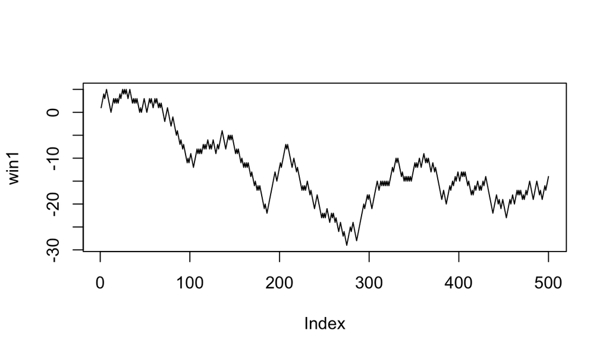

```r
w1=replicate(500,ifelse(sample(rep(c("r","b","g"),c(18,18,2)),1)=="r",1,-1))
w2=replicate(500,ifelse(sample.int(38,1)==8,35,-1))

win1=cumsum(w1)
win2=cumsum(w2)

# simple plots
plot(win1, type="l")
```

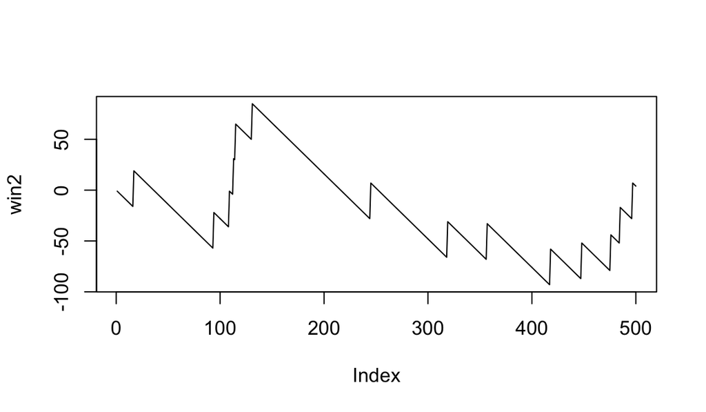

```r
plot(win2, type="l")
```

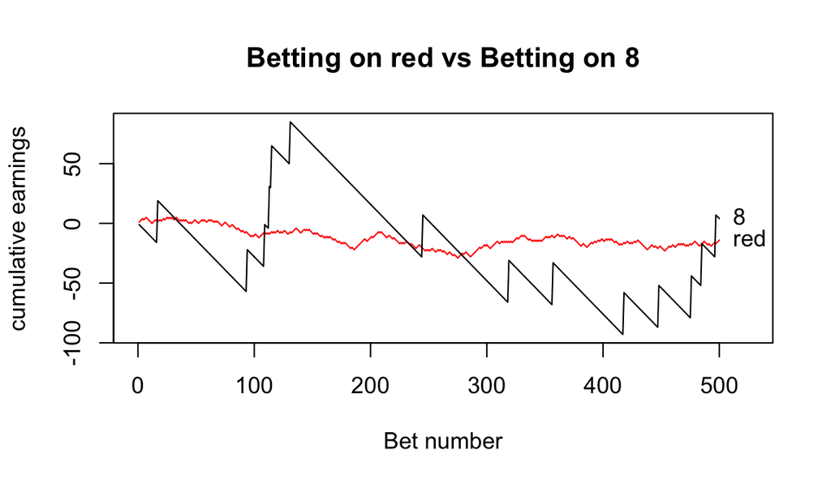

```r
# fancy plot
plot(1:500, win1, type = "n",
     ylim=c(min(c(win1,win2)),max(c(win1,win2))),
     xlim=c(0,525),
     xlab="Bet number",
     ylab="cumulative earnings",
     main="Betting on red vs Betting on 8")
lines(1:500,win1,col="red")
lines(1:500,win2,col="black")
text(x=rep(500, 2), y=c(win1[500], win2[500]), pos=4, labels=c('red', '8'))
```

**BONUS** Let’s play a game. I will hide a dime under one of three walnut shells. You make an initial guess as to which shell covers the dime. Then, I turn over one shell that does not cover the dime and give you the opportunity to either (a) stick with your initial guess; or (b) change your guess. What should you do? Let’s call strategy 1 the strategy of sticking with your initial guess and strategy 2 the strategy of always switching your guess after an empty walnut shell is revealed. Is one strategy better than the other in the long run? Can you write some code to tackle this question?

```r
# First we define a function that executes switching your guess according to Strategy 2

strategy2 <- function(shells,dime,init.guess){
  shell.reveal <-sample(intersect(setdiff(shells,dime),setdiff(shells,init.guess)),1)
  switch.guess <- setdiff(shells,union(init.guess,shell.reveal))
  return(switch.guess)
}

# Now we play 10000 games following strategy 1, and also following strategy 2.

trials=10000
shells=c("a","b","c") #the shells!
st1=c() # where we record our results from playing strategy 1
st2=c() # results of strategy 2

for (i in 1:trials){
  dime <- sample(shells,1) #place dime under a shell
  init.guess <- sample(shells,1) # make a (random) initial guess
  guess1=init.guess # strategy 1 sticks with the guess.
  guess2=strategy2(shells,dime,init.guess) # strat 2 we switch after empty shell removed
  # then we update our results
  st1=c(st1,ifelse(guess1==dime,"win","lose"))
  st2=c(st2,ifelse(guess2==dime,"win","lose"))
}
table(st1)
```

```
## st1
## lose  win
## 6778 3222
```

```r
table(st2)
```

```
## st2
## lose  win
## 3222 6778
```

What’s going on here?